# s-mobile

## S-Mobile: Predicting Customer Churn

- Team-lead GitLab id: juespino
- Group name: Team17
- Team member names: Julian Espinoza Martinez, Praveen Kumar Basker, Haritha Parupudi, William Quinn

```python
import matplotlib as mpl
import matplotlib.pyplot as plt
import numpy as np
import pandas as pd
import pyrsm as rsm
import statsmodels.formula.api as smf
from sklearn import preprocessing
from statsmodels.genmod.families import Binomial
from statsmodels.genmod.families.links import logit

# increase plot resolution
# mpl.rcParams["figure.dpi"] = 150
```

```python
## load the data - this dataset must NOT be changed
s_mobile = pd.read_pickle("data/s_mobile.pkl")
s_mobile["churn_yes"] = (s_mobile["churn"] == "yes").astype(int)
```

```python
# run python code from another notebook
%run working_haritha.ipynb
```

## 1) EDA & Model

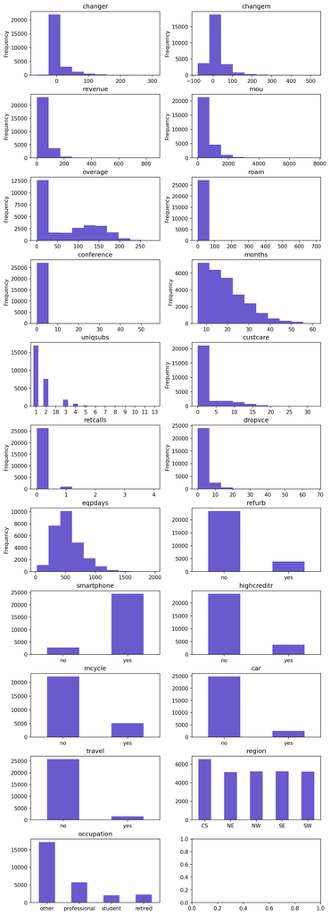

```python
%run eda.ipynb
```

Before building a logistic model, we did exploratory data analysis (in `eda.ipynb`) to understand the distributions of every variable, as seen in the training sample. Although we notice some of the explanatory variables to be skewed, we do not need to transform them for the sake of this logistic model.

The `changer` and `changem` variables are heavily skewed, but most of the values are close to 0, suggesting that the data for each customer is more or less around the same in terms of revenue and monthly usage over the span of the 4 months & 30 days of the data collection. The distributions for `revenue` and `mou` also look very similar. The plots for `overage` and `eqpdays` look the most interesting with no clear trend in distribution, thus suggesting they may have an impact on the response variable of our model. The plots for `roam`, `retcalls`, `dropvce`, and `conference` are very heavily skewed with the majority of the customers having values close to 0 for these attributes.

While the plot for `uniqsubs` has some variability, there is no apparent trend. For the categorical variables, including `refurb`, `smartphone`, `highcreditr`, `mcycle`, `car`, and `travel` the distribution is disproportionate, with the percentage of **no** being higher for all but a variable: `smartphone`.

```python
s_mobile[s_mobile["representative"] == 1].churn.value_counts()
```

```
no     29400
yes      600
Name: churn, dtype: int64
```

In the representative data, since we observe a difference of 294:6 in the churn_yes and churn_no rates, the case weights will be 294:6 (reduced to 49:1). These case weights will be used to build the regression model.

With the insights from our EDA, we built the baseline logistic model with `churn_yes` as the response variable and all the other variables as explanatory variables with `cweights` of 1:49. Looking at the odds plot for the model showed many variables with OR approximately equal to 1.

To accurately visualize the odds and look at the importance of the explanatory variables, we used standardized numeric variables as the model input to check the odds plot and importances. Based on this model, we were able to get the importances of all the explanatory variables.

```python
importances.head(5)
```

|  | index | OR | OR% | 2.5% | 97.5% | p.values |  | dummy | importance | wmean | wstd | min | max |
| --- | --- | --- | --- | --- | --- | --- | --- | --- | --- | --- | --- | --- | --- |
| 0 | occupation[T.retired] | 0.184 | -81.6% | 0.166 | 0.205 | < .001 | *** | True | 5.422 | 0.137 | 0.344 | 0.0 | 1.0 |
| 1 | highcreditr[T.yes] | 0.483 | -51.7% | 0.455 | 0.513 | < .001 | *** | True | 2.069 | 0.180 | 0.384 | 0.0 | 1.0 |
| 2 | occupation[T.student] | 1.900 | 90.0% | 1.788 | 2.018 | < .001 | *** | True | 1.900 | 0.055 | 0.227 | 0.0 | 1.0 |
| 3 | eqpdays | 1.828 | 82.8% | 1.751 | 1.909 | < .001 | *** | False | 1.828 | 510.298 | 222.647 | 22.0 | 1982.0 |
| 4 | overage | 1.786 | 78.6% | 1.706 | 1.870 | < .001 | *** | False | 1.786 | 61.625 | 67.964 | 0.0 | 283.0 |

### Alternate Model: XGBoost & Tuned Logistic Regression

As an alternative to the logistic regression model, we built both a boosted tree model (in `alternate.ipynb`), which allows for greater hyper parameter tuning, and a tuned logistic regression model, in which we looked at non-linear relationships. When we built the boosted tree model, the top 5 permutation importances varied in order from the importances calculated with the initial (standardized) regression model above.

```python
importances_alt.head()
```

|  | index | OR | OR% | 2.5% | 97.5% | p.values |  | dummy | importance | wmean | wstd | min | max |
| --- | --- | --- | --- | --- | --- | --- | --- | --- | --- | --- | --- | --- | --- |
| 0 | ov_cubed | 26.458 | 2545.8% | 21.686 | 32.280 | < .001 | *** | False | 26.458 | 0.066 | 0.277 | -0.093 | 4.320 |
| 1 | occupation[T.retired] | 0.152 | -84.8% | 0.136 | 0.170 | < .001 | *** | True | 6.583 | 0.137 | 0.344 | 0.000 | 1.000 |
| 2 | ov_2 | 0.219 | -78.1% | 0.184 | 0.262 | < .001 | *** | False | 4.557 | 0.250 | 0.223 | 0.000 | 2.652 |
| 3 | highcreditr[T.yes] | 0.496 | -50.4% | 0.467 | 0.527 | < .001 | *** | True | 2.015 | 0.180 | 0.384 | 0.000 | 1.000 |
| 4 | revenue | 0.499 | -50.1% | 0.458 | 0.543 | < .001 | *** | False | 2.006 | -0.000 | 0.500 | -0.653 | 9.175 |

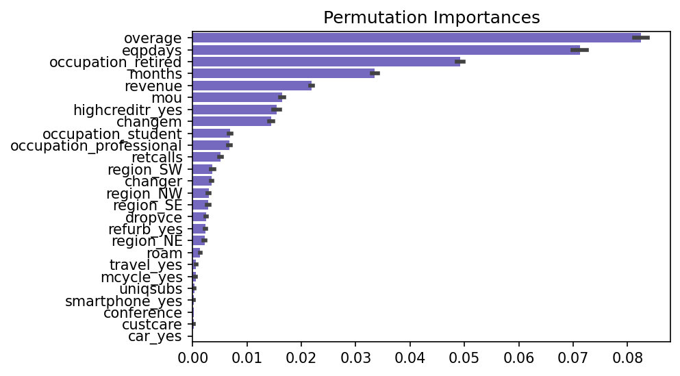

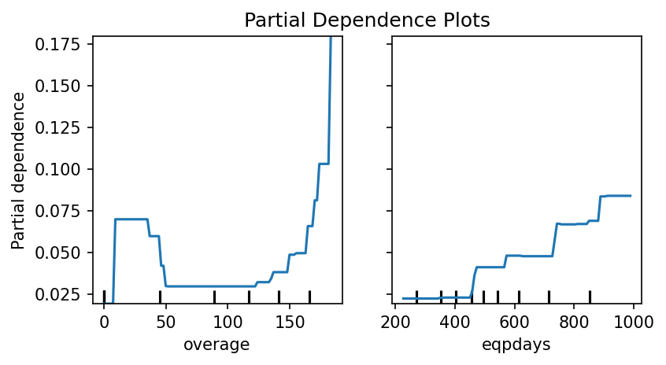

```python
%run alternate.ipynb
```

The two *Partial Dependence Plots* display the partial dependence of the variables `overage` and `eqpdays` on the `churn_yes` rate .

In the `overage` plot, the variability in dependence suggests a non-linear relationship between the `overage` and churn rate, which we further confirmed with the tuned logistic regression model.

As for the plot with `eqpdays` on the x-axis, we observe a step-wise relationship between the `eqpdays` variable and churn rate.

```python
[act_pred, lr_pred, clf_pred]
```

```
[0.02040816326530612, 0.0198, 0.02038]
```

The first value here is the actual probability, while the other two values are the prediction probabilities of the two models. The proximity of the latter two with the first value help us conclude that predicted probabilities in the representative dataset are scaled appropriately.

With this insight, combined with the fact that interpretability of the results is the most important factor, we are now able to confidently move ahead with the baseline logistic regression model we built above.

## 2) Churn Factors

The variables are listed in decreasing order of importance as follows :

- occupation(T.retired) (*5.422*): With odds of 0.184, relative to the user whose occupation is other, the odds of the retired user churning is 81.6% less keeping other variables constant.
- highcreditr(T.yes) (*2.069*): With odds of 0.483, a user with high credit rating has 51.7% less odds of churning, keeping other variables constant.
- occupation(T.student) (*1.900*):With odds of 1.90, relative to the user whose occupation is other, the odds of a student user churning is 90% higher keeping other variables constant.
- eqpdays (*1.828*): Since the odds-ratio (1.828) is greater than 1, this means that the odds of a customer churning increases as the value of `eqpdays` increases keeping other variables constant.
- overage (*1.786*):Since the odds-ratio (1.786) is greater than 1, this means that the odds of a customer churning increases as the value of `overage` increases keeping other variables constant.

Of these 5 variables the two `occupation` variables and `highcreditr` are customer characteristic variables, `eqpdays` is a equipment characteristic variable, and `overage` is a customer usage variable. Churn, as a result from the level of `occupation` and `highcreditr`, is something that we decided was out of scope for customer retention and shall only be useful in the acquisition stages. `Overage` and `epqdays` were the two variables of the highest importance that we see as the controllable factors to reduce churn.

From the churn drivers above, we chose to develop offers/incentives for the controllable variables `overage` and `eqpdays`.

## Overage (Customer Usage)

### 3) Actions/ Offers/ Incentives

`Overage` is a customer usage characteristic, and the action targeting this variable can alter customer behavior with respect to the churn. Looking at fees for higher overages in the bill prompts customers to wonder if they are with the right plan or right company as per their usage.

From the company’s perspective, `overage` generates a lot of profit, and as such, it is one of the most important factors of churn as well. The revenue from `overage` minutes is always impulsive and a strategy should be devised to reduce the `overage` and include it as part of the `mou`. We have decided that retaining the customer will be more profitable for S-Mobile in the long-term. To do so, the plan we are offering customers will help subsidize `overage` costs.

1) `overage` is less than 100 minutes: completely subsidize `overage` costs. While this means we are taking a hit on our short term profit, we expect to eventually gain profit in the long run. We anticipate this also altering customer behavior by motivating customers to stay under 100 minutes of `overage` minutes in future cycles.

2) `overage` more than 100 mins: promotional campaign where 100 mins of their total overage will be subsidized at 50%. Idea that frequent warnings will prompt a heavy user to try and upgrade to the higher plan.

### 4) Quantify Actions

Action/Plan: Subsidize the customer’s overage minutes if the ratio of `overage` minutes to `mou` is under 10%

```python
s_mobile_2[(s_mobile_2.ovs > 0) &(s_mobile_2.ovs < 0.10)].loc[s_mobile_2.overage > 0, ["churn_yes", "p_overage1_3"]].agg(
    ["count", "mean"]
).round(4)
```

|  | churn_yes | p_overage1_3 |
| --- | --- | --- |
| count | 3415.0000 | 3415.0000 |
| mean | 0.0176 | 0.0112 |

### 5) Target Customers

Targeting rule: customers whose `overage` minutes are less than 10% of their monthly usage. The number of customers falling into that criteria is `3415`.

### 6) Economics

Assumptions considered while calculating the profitability:

- Despite the variations in revenue in each customer, we are considering the average revenue of the subset considered in CLV calculation.
- The service cost is assumed to be 10%
- The overage’s per minute cost is assumed to be 0.1 SGD
- The period considered for CLV is 60 months

```python
p2_a - p2_b
```

```
Offer CLV
CLV    115.001
Name: Month 60, dtype: float64
```

Plan economics:

- The CLV of a customer from the subset who has overage of 10% or less is 2266.3 SGD before subsidizing.
- The CLV of the same customer after subsidizing is 2381.3 SGD
- The Profitability at the month 60 is 115 SGD
- The average revenue for ‘after subsidizing’ CLV calculation is adjusted to take into account the reduction in the revenue due to subsidizing.

## Eqpdays (Equipment characteristic)

### 3) Actions/ Offers/ Incentives

Since this variable is an equipment characteristic variable that describes the number of days the user has been using the current device, the action cannot directly alter a behavior. Instead, we will focus on offering an incentive in which the customer has the choice of changing this characteristic, and thus becoming a part of a new subset of customers, one which will likely result in a lower churn rate.

Logically, if a customer owns an older device, they are more likely to churn because they have the chance of being encouraged to switch providers for a new device or exposed to offers to upgrade their device from another carrier. This is the leverage that we will use, and we will expose a subset of customers, who have devices older than a certain threshold, to an upgrade offer.

If the user interacts with the offer and upgrades their device with S-Mobile, they become part of the customer base that have a lower churn rate because they tend to stay longer either by expanding their contract or being less tempted by other competitors' offers.

### 4) Quantify Actions

Identify customers whose devices are older than 365 days and send a device upgrade offer. As we cannot run the experiment, we assume that, of the customers mailed, 10% will respond by upgrading the device.

```python
s_mobile_eqp[s_mobile_eqp['customer'].isin(resp_list)][["churn_yes", "p_eqp"]].agg(
    ["count", "mean"]
).round(4)
```

|  | churn_yes | p_eqp |
| --- | --- | --- |
| count | 2188.0000 | 2188.0000 |
| mean | 0.0192 | 0.0096 |

### 5) Target Customers

Customers that have a device older than 365 days and accepted the promotional offer. The number of customers mailed were 21880 customers and with the assumption that 10% of the customers accept the offer, our subset that is considered is `2188` customers.

### 6) Economics

```python
p3_a - p3_b
```

```
Offer CLV
CLV    352.761
Name: Month 60, dtype: float64
```

Plan economics:

- The CLV of a customer from the subset who accepted to upgrade their device is 1341.5 SGD before upgrading
- The CLV of the same customer after upgrading the device is 1694.3 SGD
- The Profitability at the end of month 60 is 352.8 SGD
- The promotional discount on the renewal of discount shall be ranging from 100 - 200 SGD based with the expected profitability still high in the range of 252.8 - 152.8 SGD